# Initial RadNet Envirofacts Download

Annelise Blomberg

April 13, 2018

# Introduction

We are working on downloading RadNET data from the Envirofacts API (instead of downloading by hand). The EPA has a REST API for interacting with Envirofacts: https://www.epa.gov/enviro/envirofacts-data-service-api

I access the data using the package “httr”

There are 11 RadNET tables available from Envirofacts. The following figure is from the EPA website (https://www.epa.gov/enviro/radnet-model), and shows how all the tables connect to each other.

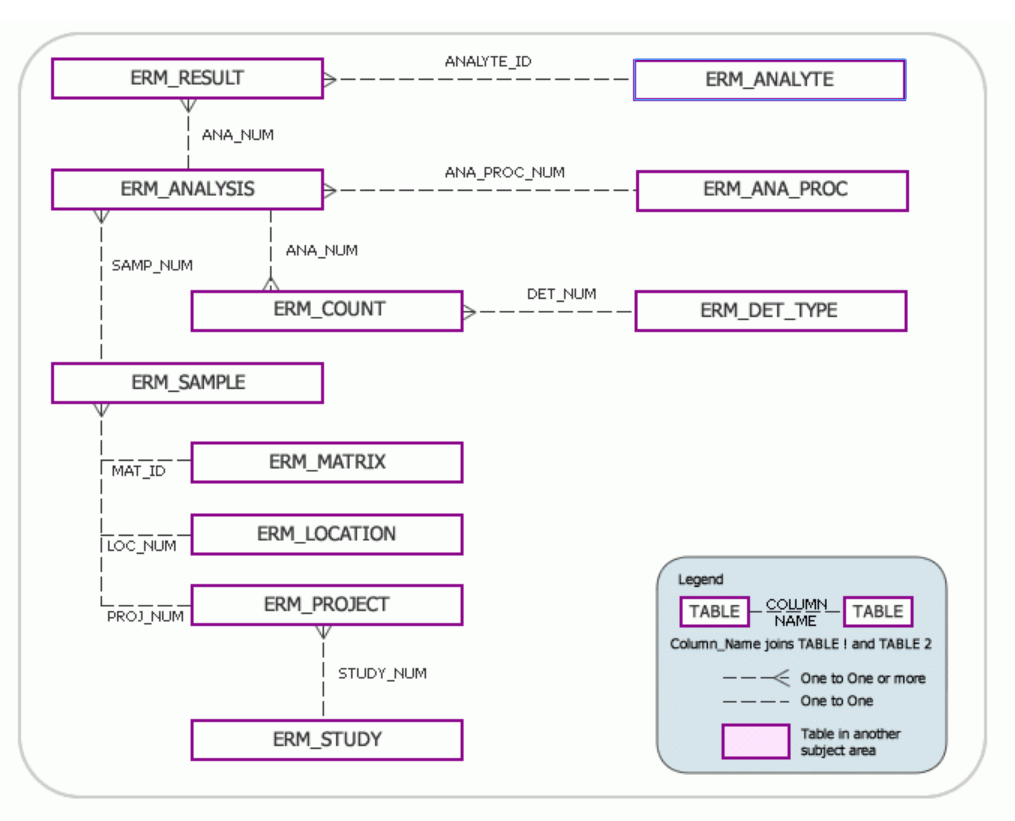

RadNet Model

This markdown file is a quick review of what information is available in each table.

# Download Table Lengths

We start by making a list of all files and downloading the total counts of entries for each one.

```r
table.list <- as.list(c("ERM_ANALYTE", "ERM_RESULT", "ERM_ANALYSIS", "ERM_COUNT", "ERM_DET_TYPE", "ERM_ANA_PROC", "ERM_SAMPLE", "ERM_MATRIX", "ERM_LOCATION", "ERM_PROJECT", "ERM_STUDY"))

GetTableLength <- function(table) {
        url <- "http://iaspub.epa.gov/enviro/efservice"
        url2 <- paste(url, table, "JSON", "count", sep = "/")
        results <- GET(url2)
        TableLength <- flatten(content(results))[[1]]
}

# test <- GetTableLength("ERM_ANA_PROC")

table.lengths <- map(table.list, GetTableLength)
names(table.lengths) <- table.list
table.lengths2 <- t(bind_rows(table.lengths))
table.lengths3 <- as.tibble(table.lengths2, rownames = "Table") %>%
        rename(Length = V1) %>%
        arrange(Length)

library(kableExtra)
knitr::kable(table.lengths3, "html") %>%
        kable_styling(full_width = F, position = 'left')
```

| Table | Length |
| --- | --- |
| ERM_MATRIX | 6 |
| ERM_STUDY | 10 |
| ERM_ANALYTE | 65 |
| ERM_ANA_PROC | 172 |
| ERM_LOCATION | 331 |
| ERM_DET_TYPE | 424 |
| ERM_PROJECT | 1094 |
| ERM_SAMPLE | 277959 |
| ERM_ANALYSIS | 324868 |
| ERM_COUNT | 327312 |
| ERM_RESULT | 512077 |

# Download (7) smaller tables

From the table lengths, we see that some of the tables are smaller, so must be crosswalks/metadata of a sort rather than sample information. We download these smaller tables.

```r
small.table.list <- as.list(c("ERM_ANALYTE", "ERM_DET_TYPE", "ERM_ANA_PROC", "ERM_MATRIX", "ERM_LOCATION", "ERM_STUDY", "ERM_PROJECT"))

GetTableContent <- function(table){
        url <- "http://iaspub.epa.gov/enviro/efservice"
        url2 <- paste(url, table, "CSV", sep = "/")
        results <- GET(url2)
        results.content <- content(results)

        # Rename table column names to drop the table prefix
        names.long <- names(results.content)
        names.short <- str_sub(names.long, start = str_length(table) + 2)
        names(results.content) <- names.short

        return(results.content)
}

table.content <- map(small.table.list, GetTableContent)
names(table.content) <- small.table.list
```

It looks like every table is loading an empty last-column. Is this the case?

```r
CheckLastCol <- function(table){
        last.col <- dim(table)[2]
        unique(table[last.col])
}
test_lastcol <- map(table.content, CheckLastCol)
# Print out first three
test_lastcol[1:3]
```

```
## $ERM_ANALYTE
## # A tibble: 1 x 1
##   ``
##   <chr>
## 1 <NA>
##
## $ERM_DET_TYPE
## # A tibble: 1 x 1
##   ``
##   <chr>
## 1 <NA>
##
## $ERM_ANA_PROC
## # A tibble: 1 x 1
##   ``
##   <chr>
## 1 <NA>
```

We see that the last column is empty for all tables, so we drop it.

```r
DropLastCol <- function(table){
        last.col <- dim(table)[2]
        table2 <- table[, -last.col]
}

table.content2 <- map(table.content, DropLastCol)
```

Save the tables into the global environment.

```r
list2env(table.content2, envir=.GlobalEnv)
```

```
## <environment: R_GlobalEnv>
```

## Look at individual tables

We have seven tables with crosswalk information.

ERM_ANALYTE: gives ANALYTE_ID and ANALYTE_NAME for all 65 analyte types.

| ANALYTE_ID | ANA_TYPE | HALF_LIFE | HALF_LIFE_TIME_UNIT | ANALYTE_NAME | CRS_ID |
| --- | --- | --- | --- | --- | --- |
| AC228 | R | 6.130 | H | Actinium-228 | NA |
| ALPHA | R | NA | NA | Gross Alpha | NA |
| AM241 | R | 432.200 | Y | Americium-241 | NA |
| BA133 | R | 10.500 | Y | Barium-133 | NA |
| BA140 | R | 12.789 | D | Barium-140 | NA |
| BE7 | R | 53.440 | D | Beryllium-7 | NA |

ERM_DET_TYPE: I have no idea what this is.

| DET_NUM | DET_ID | DET_TYPE_ID |
| --- | --- | --- |
| 1 | UNK | UNK |
| 2 | AS | AS |
| 3 | HPGE | HPGE |
| 4 | GELI | GELI |
| 5 | LBAB | GPC |
| 6 | LBB | LBB |

ERM_ANA_PROC: this gives a procedure name and procedure ID>. Each procedure is connected to an analysis.

| ANA_PROC_NUM | ANA_PROC_ID | PROC_TYPE_ID | ANA_PROC_NAME |
| --- | --- | --- | --- |
| 1 | AIRBETA | AIRBETA | Gross beta in air |
| 2 | ALPBET | ALPBET | Gross alpha-beta |
| 3 | ALPHA | ALPHA | Gross alpha |
| 4 | ALPHACO | ALPHA | Gross alpha |
| 5 | AM | AM | Americium |
| 6 | BETA | BETA | Gross beta |

ERM_MATRIX: this is the matrix from which the sample was collected. There are only six matrix types (including air filters)

| MAT_NUM | MAT_ID | MAT_DESC |
| --- | --- | --- |
| 7 | PASTEURIZED MILK | Milk |
| 10 | PRECIPITATION | Precipitation |
| 11 | DRINKING WATER | Drinking water |
| 13 | SURFACE WATER | Surface water |
| 26 | AIR-CHARCOAL | Charcoal cartridge |
| 30 | AIR-FILTER | Air filter |

There are 331 ERM_LOCATIONs and 1094 ERM_PROJECTs. Some locations have multiple projects.

| LOC_NUM | STATE_ABBR | CITY_NAME | SURFACE_WATER_SOURCE | STATION |
| --- | --- | --- | --- | --- |
| 1 | AL | MONTGOMERY | NA | MONTGOMERY |
| 2 | AL | BIRMINGHAM | NA | BIRMINGHAM |
| 3 | AL | MOBILE | NA | MOBILE |
| 5 | AL | DOTHAN | Chattahoochee River | DOTHAN |
| 6 | FL | TALLAHASSEE | NA | TALLAHASSEE |
| 7 | FL | MIAMI | NA | MIAMI |

| PROJ_NUM | STUDY_NUM | PROJ_ID | PROJ_NAME |
| --- | --- | --- | --- |
| 40 | 1 | PMN 1978-4 | PMN 1978-4 |
| 41 | 4 | DW 1978-4 | DW 1978-4 |
| 42 | 5 | SW 1978-4 | SW 1978-4 |
| 53 | 3 | TR 1978-3 | TR 1978-3 |
| 54 | 1 | PMNC 1978-4 | PMNC 1978-4 |
| 57 | 5 | SW 1978-3 | SW 1978-3 |

There 10 ERM_STUDYs.

| STUDY_NUM | STUDY_ID | STUDY_NAME |
| --- | --- | --- |
| 1 | PMN | RadNet Pasteurized Milk Network |
| 2 | RAN | RadNet Radiation Alert Network |
| 3 | TR | RadNet Precipitation Network |
| 4 | DW | RadNet Drinking Water Network |
| 5 | SW | ERAMS Surface Water Network |
| 24 | KR | ERAMS Kr-85 in Air |
| 25 | TR - RAIN | RadNet TR - Individual rain samples |
| 26 | RAN - PUUA | RadNet RAN - Annual composites |
| 27 | DWCP | RadNet DW - Annual composites |
| 30 | FNI | Fukushima Nuclear Incident |

```r
SaveFiles <- function(table, table.name){
        save.name <- paste0(table.name, ".csv")
        print(save.name)
        write_csv(table, path = here::here("data", save.name))
}

walk2(.x = table.content2, .y = names(table.content2), SaveFiles)
```

```
## [1] "ERM_ANALYTE.csv"
## [1] "ERM_DET_TYPE.csv"
## [1] "ERM_ANA_PROC.csv"
## [1] "ERM_MATRIX.csv"
## [1] "ERM_LOCATION.csv"
## [1] "ERM_STUDY.csv"
## [1] "ERM_PROJECT.csv"
```

# Investigate (4) bigger tables

The largest tables in RadNet Envirofacts are:

- ERM_RESULT (512077)
- ERM_ANALYSIS (324868)
- ERM_COUNT (327312)
- ERM_SAMPLE (277959)

From the metadata available online, we can see what is in each table without downloading.

- ERM_RESULT
  - ANALYTE_ID, ANA_NUM, CSU, MDC
  - RESULT_AMOUNT, RESULT_DATE, RESULT_ID, RESULT_UNIT
- ERM_ANALYSIS
  - ANA_COMMENT, ANA_NUM, ANA_PROC_NUM, ANA_SIZE, ANA_UNIT, SAMP_NUM
- ERM_SAMPLE
  - CLIENT_ID, COLLECT_END, COLLECT_START, LOC_NUM, MAT_ID, PROJ_NUM
  - SAMP_COMMENT, SAMP_DESC, SAMP_ID, SAMP_NUM, SAMP_SIZE, SAMP_UNIT

It looks like most of this will be important.